# Lidar Tutorial

This tutorial is an introduction to working with the products of lidar data collection from airborne platforms (e.g., drones) using the statistical software `R`, specifically the library `lidR`.

*Language:* `R`

*Packages:*

| Name | Description | Link |
| --- | --- | --- |
| `lidR` | Package to view and process LiDAR point clouds in `R` | https://cran.r-project.org/web/packages/lidR/index.html |
| `future` | Package to enable parallel processing for more efficient computation | https://cran.r-project.org/web/packages/future/index.html |

## Nomenclature

- *lidar:* Light Detection and Ranging, a method of remote sensing using pulsed lasers to measure distances.
- *LAS:* A file format for storing the 3D point cloud data collected by LiDAR. A related file format is LAZ, which is the compressed version of LAS.
- *Pulse:* A discrete “shot” of laser emission from the LiDAR platform that is used to measure distance from the target surface, which in turn are the basis of point cloud data.

## Data Details

We will use point cloud data collected over the [U.S. Dairy Forage Research Center Far](https://www.ars.usda.gov/ARSUserFiles/50901500/About%20Us%20and%20Contact%20Information/pdfs/farm%20at%20PdS.pdf) by the [3D Elevation Program](https://www.usgs.gov/3d-elevation-program), a program at the USGS that is conducting nationwide LiDAR surveys.

- Repository: [USGS National Map](https://apps.nationalmap.gov/lidar-explorer/#/)
- Dataset name: The datasets we are using are a subset of the elev3dep project [WI_8County_2020_A20](https://rockyweb.usgs.gov/vdelivery/Datasets/Staged/Elevation/LPC/Projects/WI_8County_2020_A20/WI_8County_Sauk_2020/LAZ/)
- *Note that the data are available in the tutorial folder*

## Anlysis Steps

- Load in LAS data
- Exploring the LAS data structure in `lidR`
  - Attributes
  - Plotting
- Larger geographic coverage with the `lasCatalog` in `lidR`

## Step 0: Load Libraries and data

```r
library(lidR)
library(future)
library(devtools)
library(ggplot2)
library(tidyverse)
library(rgl)

# Here is the directory on Atlas
lasdir <- "./data"

# look at the contents of the folder:
lasfiles <- list.files(lasdir, full.names=TRUE)
```

### Exploring the LAS data structure in `lidR`

Individual lidar point clouds (lasfiles) are loaded using the function `readLAS`. Read in one of the dataset point clouds using `readLAS`:

```r
las <- readLAS(lasfiles[1])
```

If you’re using R or Rstudio on a local machine with an X11 server set up, you can plot it in 3D using the `plot` command in `lidR`. Unfortunately, this doesn’t seem to work in Rstudio server on Open OnDemand.

Note that you can specify what attribute to plot using the `color` argument. Try plotting by `Classification`.

```r
# This won't run on Rstudio Server
# plot(las, color = "Classification")
```

## Step 1: Outlier removal

First we will do some noise removal. We will read in a new tile ignoring the classification information to pretend it hasn’t been done yet.

We will try using the isolated voxel filter function (`ivf`). It identifies points points that have very few pixels in their surrounding neighborhood of volumetric pixels (‘voxel’). The `res` parameter is the resolution (size) of the voxels defining the neighborhood, and `n` defines threhold number of other points to be considered ‘isolated’.

```r
las_unclass <- readLAS(lasfiles[1], select="xyzrn")
las_denoise <- classify_noise(las_unclass, algorithm = ivf(res=15, n = 6))

#plot(las_denoise, color = "Classification")
```

If we were able to plot the pointcloud in 3D we would see that the `ivf` function has identified some isolated points above and below the main point cloud, and also identified points that are probably powerlines.

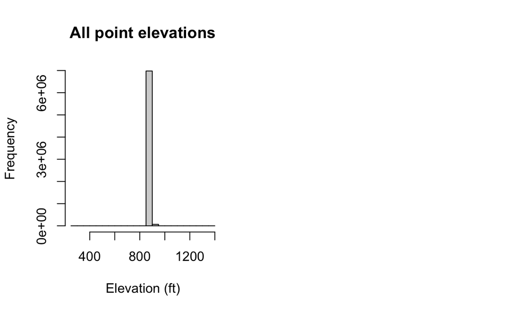

```r
# filter out the points that were classified as noise
las_nonoise <- filter_poi(las_denoise, Classification != LASNOISE)

par(mfrow=c(1,2))

hist(las_unclass$Z, main="All point elevations", xlab="Elevation (ft)")
hist(las_nonoise$Z, main="Filtered point elevations", xlab="Elevation (ft)")
```

## Step 2: Classifying the ground

Now we will try classifying the ground for this lidar tile. We’re going to use the ground classification algorithm `pmf`, which stands for ‘progressive morphological filter’.

```r
# we need to set up the ground classification parameters

las_gnd <- classify_ground(las_nonoise, algorithm = pmf(ws = 15, th = 9))
```

[output not shown]

[output cut: 41 more lines]

[output not shown]

```r
# view classification results in 3D:

#plot(las_gnd, color = "Classification")
```

To get a better idea of how the classification worked, we can plot a cross section in ggplot. There is a function in `R/plot_cross.r` that can be used for this.

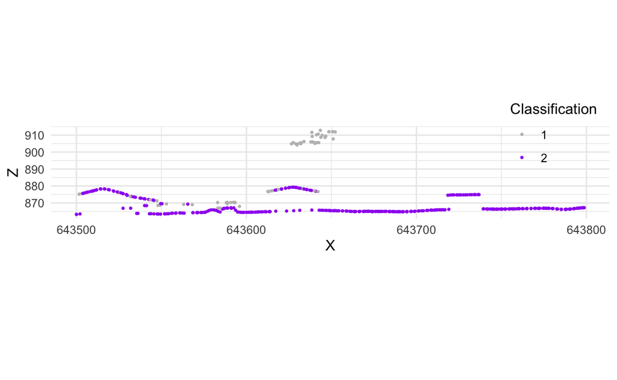

```r
source("R/plot_cross.r")

plot_cross(las_gnd, transect_len = 300)
```

It looks like there are buildings that are being classified as ground. We can try adding additional parameter iterations help to take care of the buildings.

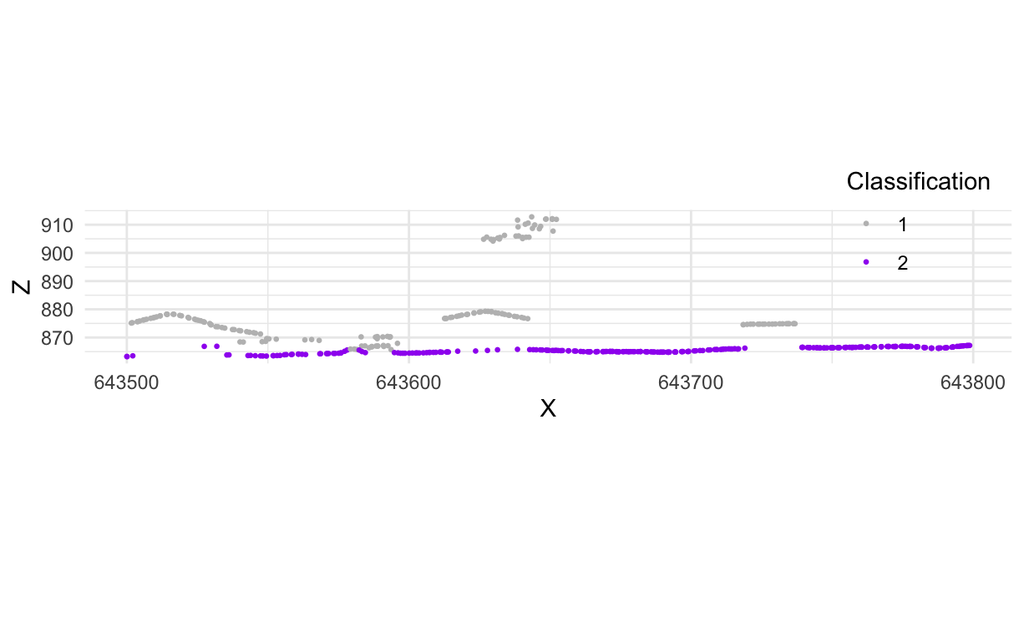

## Step 3: Create a digital terrain model

With the ground identified, we can use this information to create a digital terrain model (DTM). The DTM has a lot of applications, like for modeling hydrology. In our case, we will use the DTM to normalize the point cloud, which allows us to treat the points as if they were collected above a flat surface. This way, the height of the point in the point cloud corresponds to height above the ground in the real world. This will be helpful for modeling vegetation height.

There are also several methods of making a DTM in `lidR`. We will use the ‘triangular irregular network’ approach, which is a fast and robust method. It uses the Delauney triangulation method, which is simple and requires no parameters.

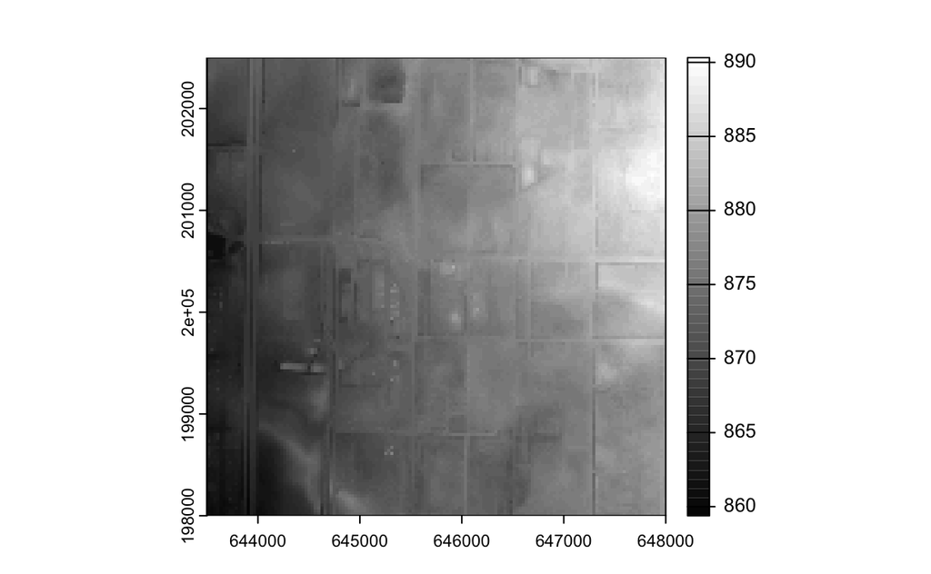

Another approach is to use nearest neighbor interpolation with inverse distance weighting:

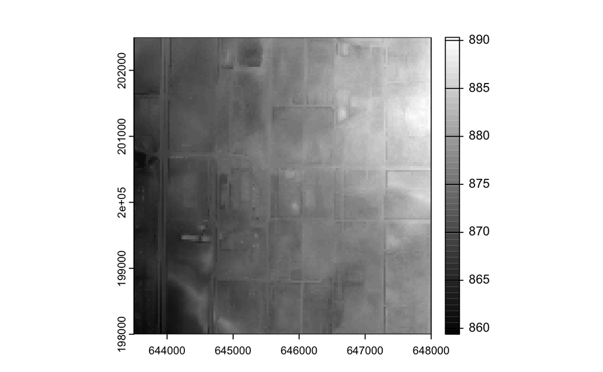

```r
dtm_idw <- rasterize_terrain(las_pmf2, res = 30,
                             algorithm = knnidw(k = 10, p = 2, rmax = 150))

# plot_dtm3d(dtm_idw, bg = "white")

plot(dtm_idw, col = gray(1:50/50))
```

## Step 4: Height normalization

Once we have the digital terrain model, we can use it to normalize the heights of the point cloud.

```r
nlas <- las_pmf2 - dtm_tin
```

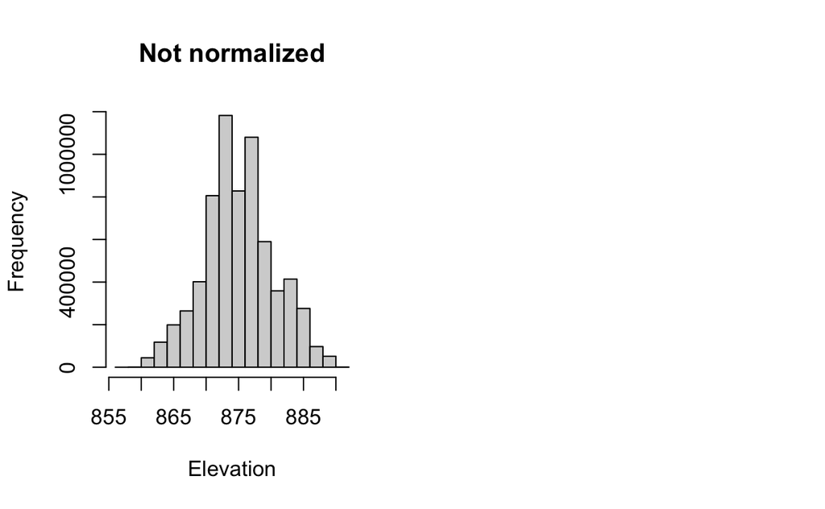

Another way to normalize the point cloud is to reference the ground points within the point cloud itself. The `normalize_height` function uses a spatial interpolation function to create a continuous surface of ground points to use for normalization rather than the DTM grid. We need to give it an interpolation method, so we use the TIN method again.

```r
nlas2 <- normalize_height(las_pmf2, tin())
```

[output not shown]

[output cut: 38 more lines]

[output not shown]

If we look at the histogram of ground points from this normalization, we can see they are all at 0.

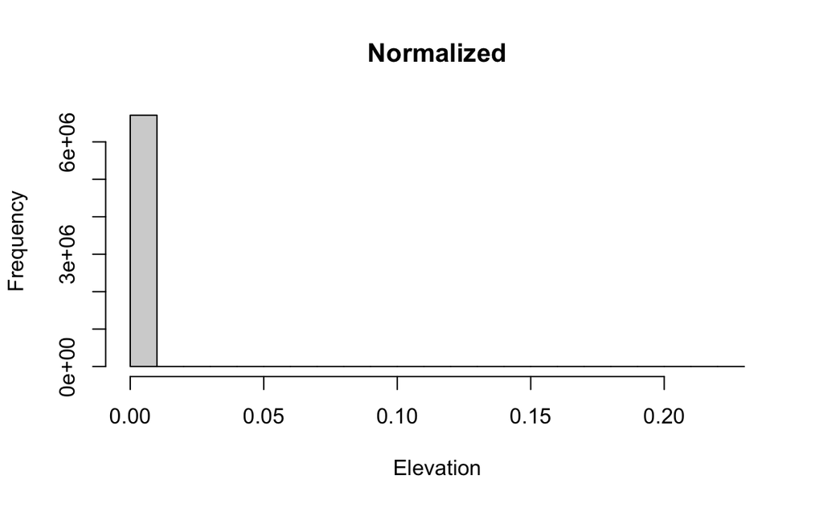

## Step 5: Canopy Height Model

Once we have normalized the las cloud by the ground elevation, we assume that the Z values of vegetation points represent their heights. Like the digital terrain model, we can use this information to make a canopy height model raster.

Like the other steps in this tutorial, `lidR` presents many options for making the canopy height model. The simplest is using the `p2r` algorithm, which stands for ‘point to raster’. It directly converts the normalized point heights to raster cells.

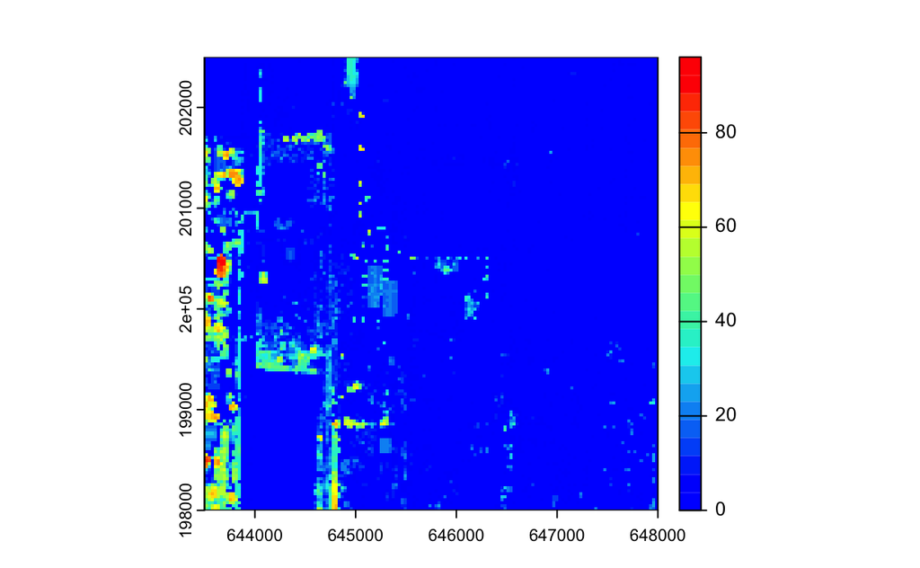

`p2r` is very fast, but it leaves holes where there is no vegetation at lower resolutions. `lidR` also has more complex algorithms that can deal with these issues but this will work for our purposes. You can read more on this in the `lidR` book.

## Step 6: Individual tree detection

We can identify individual trees using the local maximum filter algorithm `lmf`. The filter looks in a neighborhood of points to determine which point is highest. The parameter that determines the search neighborhood is `ws`, which defines the diameter of the search radius.

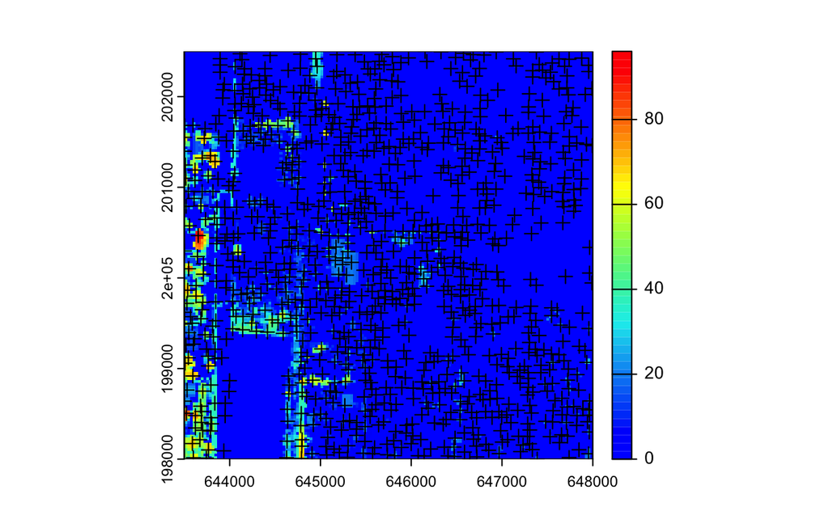

The tree detection might be improved with a variable window size. This is because we would expect shorter trees to have smaller canopies and need a smaller window to detect, while taller trees would have wider canopies and require a larger window. We can make a function defining window size as a function of height and provide that to the `lmf` function instead of a constant window size.

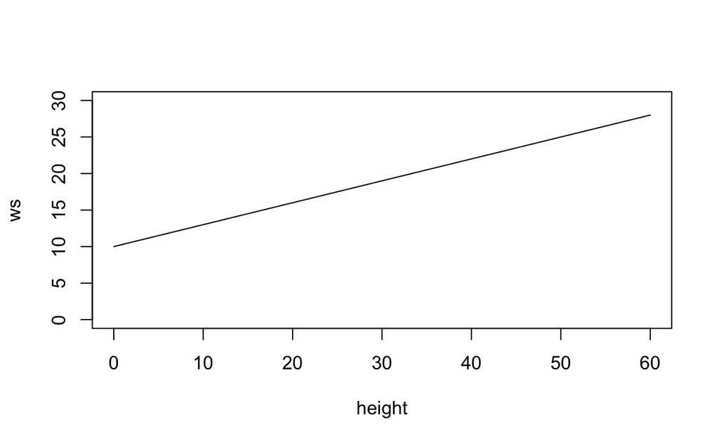

And now we can try identifying trees with our variable function!

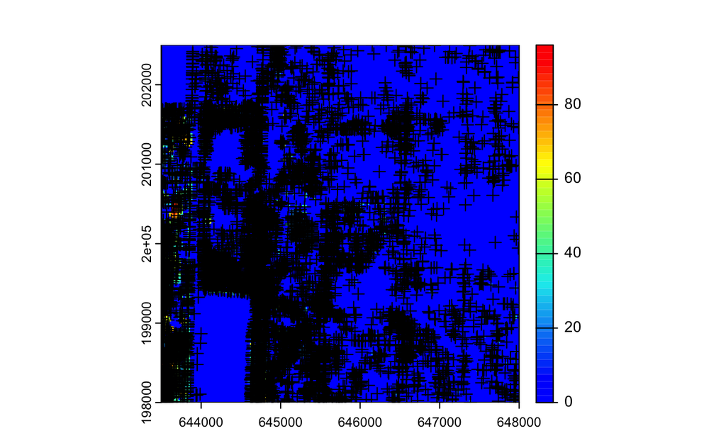

I would not say the new window function worked that well. Other functions could be developed, and with non-linear or stepwise shapes. Give it a try!

## Step 6b: Individual tree segmentation

We can also segment the point cloud by estimated trees. As always, `lidR` provides several algorithm choices. Today we’ll go with `dalponte2016`, which uses the canopy height model and estimated tree tops we just produced. We use these data to first paramterize the algorithm and apply it in the `segment_trees` function.

```r
treelas <- segment_trees(nlas2, algo) # segment point cloud
```

You may not be able to visualize the output in 3D if you’re using Atlas. We can also do a raster-based tree segmentation.

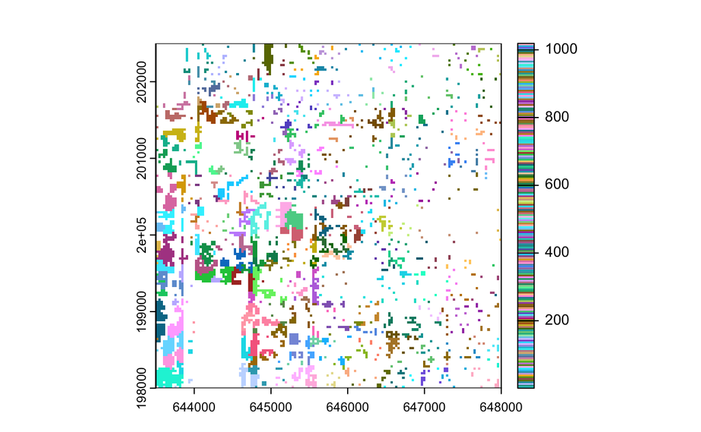

```r
crowns <- algo()
plot(crowns, col = pastel.colors(200))
```

## Bonus: Processing tiled datasets

`lidR` can handle tiled datasets in a nice way. You can load a folder of las files as tiles using the `readLAScatalog`` function.

When this is plotted, `lidR` shows the coverages of the tiles.

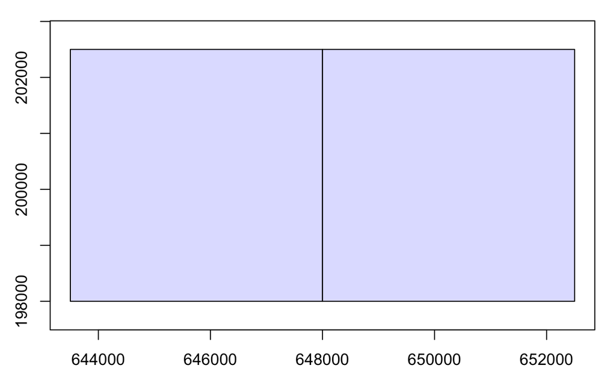

When processing LAScatalog data, `lidR` will work with individual chunks of the larger dataset. But it will also take into account a buffer area of nearby tiles so that there aren’t edge artifacts. These buffers are adjustable. You can view them below.

[figure not shown]

```r
ctg_gnd <- classify_ground(ctg, algorithm = pmf(ws = 15, th = 9))
```

You can use parallel processing to process multiple chunks simultaneously, using the `future` package. Using the `future::plan` function, you can assign multiple workers to handle separate tiles.

```r
# Check how many cores available
availableCores()

# set up multisession
plan(multisession, workers=2)
```

```r
# run your favorite lidR process in parallel on the LAScatalog! e.g.:
ctg_gnd <- classify_ground(ctg, algorithm = pmf(ws = 15, th = 9))
```

## References

Guo, Q., Su, Y., Hu, T., Guan, H., Jin, S., Zhang, J., Zhao, X., Xu, K., Wei, D., Kelly, M., & Coops, N. C. (2021). Lidar Boosts 3D Ecological Observations and Modelings: A Review and Perspective. IEEE Geoscience and Remote Sensing Magazine, 9(1), 232–257. https://doi.org/10.1109/MGRS.2020.3032713

Roussel, J.-R., Goodbody, T. R. H., & Tompalski, P. (2023). The lidR package. https://r-lidar.github.io/lidRbook/